# STATS 32 Session 2: Packages and Data Frames

Kenneth Tay

Oct 5, 2017

# Recap of session 1

- R as calculator
- Types of variables in R
- Homogeneous data structures: vectors & matrices
- Heterogeneous data structures: lists

# Vectors

- Can be created using the `c()` function, or using the `:` shortcut
- Elements in a vector have to be of the same type

```r
vec <- c(10, 5, 20)
```

```r
vec <- 1:10 * 2
vec
```

```
##  [1]  2  4  6  8 10 12 14 16 18 20
```

- To extract a subset of elements by their indices, put a vector of indices in square brackets:

```r
vec[c(1,5)]
```

```
## [1]  2 10
```

- Negative indexing:

```r
vec[-1]
```

```
## [1]  4  6  8 10 12 14 16 18 20
```

# Matrices

- 2-dimensional analog of vectors
- Created using the `matrix()` function

```r
A <- matrix(LETTERS, nrow = 2)
A
```

```
##      [,1] [,2] [,3] [,4] [,5] [,6] [,7] [,8] [,9] [,10] [,11] [,12] [,13]
## [1,] "A"  "C"  "E"  "G"  "I"  "K"  "M"  "O"  "Q"  "S"   "U"   "W"   "Y"
## [2,] "B"  "D"  "F"  "H"  "J"  "L"  "N"  "P"  "R"  "T"   "V"   "X"   "Z"
```

```r
A <- matrix(LETTERS, nrow = 2, byrow = TRUE)
A
```

```
##      [,1] [,2] [,3] [,4] [,5] [,6] [,7] [,8] [,9] [,10] [,11] [,12] [,13]
## [1,] "A"  "B"  "C"  "D"  "E"  "F"  "G"  "H"  "I"  "J"   "K"   "L"   "M"
## [2,] "N"  "O"  "P"  "Q"  "R"  "S"  "T"  "U"  "V"  "W"   "X"   "Y"   "Z"
```

- Indexing works in a similar way to that for vectors

```r
A[,1:2]
```

```
##      [,1] [,2]
## [1,] "A"  "B"
## [2,] "N"  "O"
```

# Lists

- A collection of key-value pairs
- Created with the `list()` function

```r
cars <- list(make = "Honda",
             models = c("Fit", "CR-V", "Odyssey"),
             available = c(TRUE, TRUE, TRUE))
```

- `[[` or `$` notation to refer to a specific key-value pair

```r
cars$make
```

```
## [1] "Honda"
```

```r
cars[["models"]]
```

```
## [1] "Fit"     "CR-V"    "Odyssey"
```

```r
cars[[3]]
```

```
## [1] TRUE TRUE TRUE
```

# Agenda for today

- Data frames
- Functions and packages
- Introduction to RStudio

# What is a data frame?

- A **data frame** is R’s data structure for storing datasets
  - First row: variable/covariate names
  - Each subsequent row represents one observation
  - Each column contains the values of that variable/covariate across observations
- **Tibbles**: A data frame with some cosmetic changes

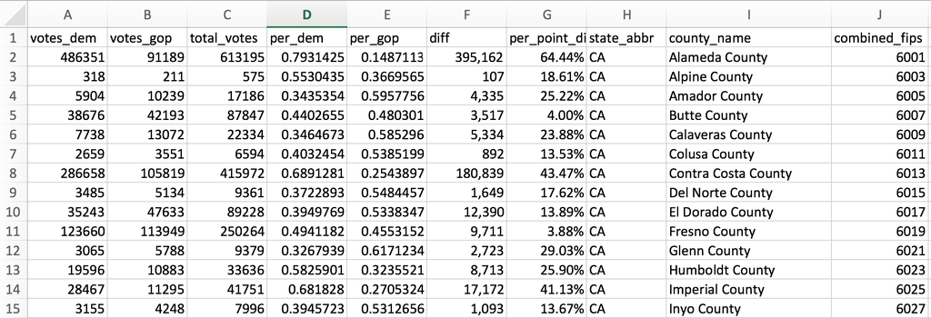

Example of a dataset

# R’s Syntax for creating data frames

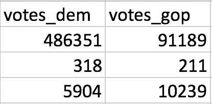

```r
df <- data.frame(votes_dem = c(486351, 318, 5904),
                 votes_gop = c(91189, 211, 10239))
df
```

```
##   votes_dem votes_gop
## 1    486351     91189
## 2       318       211
## 3      5904     10239
```

# Data frames “under the hood”

- To R, a data frame is simply a special type of list!
  - Keys of the list are the variable/covariate names
  - Values are vectors of the same length

```r
is.list(df)
```

```
## [1] TRUE
```

```r
df$votes_dem
```

```
## [1] 486351    318   5904
```

# Functions: R’s workhorse

A **function** is a named block of code which

- Takes in 1 or more inputs from the user,
- Performs a specific task, and
- Returns an output to the user.

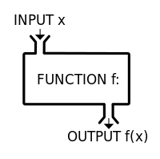

(Source: [practicalli.github.io](https://practicalli.github.io/clojure/thinking-functionally/pure-functions.html))

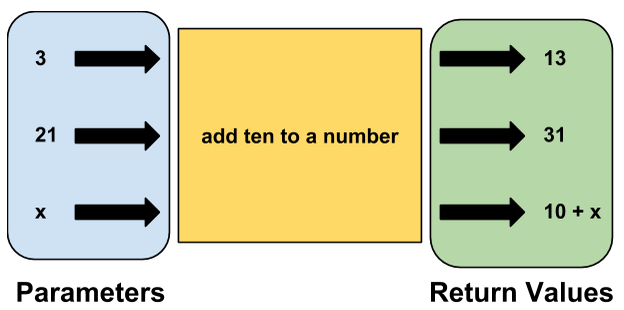

(Source: [codehs.gitbooks.io](https://codehs.gitbooks.io/introcs/content/Basic-JavaScript-and-Graphics/functions-and-return-values.html))

# Why use functions?

### Reason #1: Functions make code more understandable.

- Both for others and for you (6 months down the road)

**Example**: What is the line of code below trying to do?

```r
x <- c(4, 234, 1, 50, 764)
x <- (x - min(x)) / (max(x) - min(x))
```

```
#> [1] 0.003931848 0.305373526 0.000000000 0.064220183 1.000000000
```

```r
rescale01 <- function(x) {
  (x - min(x)) / (max(x) - min(x))
}
rescale01(c(4, 234, 1, 50, 764))
```

```
## [1] 0.003931848 0.305373526 0.000000000 0.064220183 1.000000000
```

# Why use functions?

### Reason #2: Functions make code more concise.

- **DRY** principle: **D**on’t **R**epeat **Y**ourself
- Minimize chance of making errors

```r
list$a <- (list$a - min(list$a)) / (max(list$a) - min(list$a))
list$b <- (list$b - min(list$b)) / (max(list$b) - min(list$b))
list$b <- (list$c - min(list$c)) / (max(list$c) - min(list$c))
```

vs.

```r
list$a <- rescale01(list$a)
list$b <- rescale01(list$b)
list$c <- rescale01(list$c)
```

# Why use functions?

### Reason #3: Functions enable code reuse and code changes.

```r
list$a <- (list$a - min(list$a)) / (max(list$a) - min(list$a))
list$b <- (list$b - min(list$b)) / (max(list$b) - min(list$b))
list$c <- (list$c - min(list$c)) / (max(list$c) - min(list$c))
```

vs.

```r
rescale01 <- function(x) {
  (x - min(x)) / (max(x) - min(x))
}
list$a <- rescale01(list$a)
list$b <- rescale01(list$b)
list$c <- rescale01(list$c)
```

What if I want to rescale the entries to be between 0 and 2 instead?

# We use functions in R all the time

We’ve already seen a number of functions in R! For example,

```r
is.character("123")
```

```
## [1] TRUE
```

The function `is.character` takes the input given to it in the parentheses and returns `TRUE` or `FALSE`, depending on whether the input is of type character or not.

We can see what a function does by typing in `?` followed by the function name in the R console.

```r
?is.character
```

# Structure of an R function call

A function call consists of:

- Function name
- Parentheses, and
- A list of arguments within the parentheses
  - Options that change what the function does slightly

# `matrix()`: Description

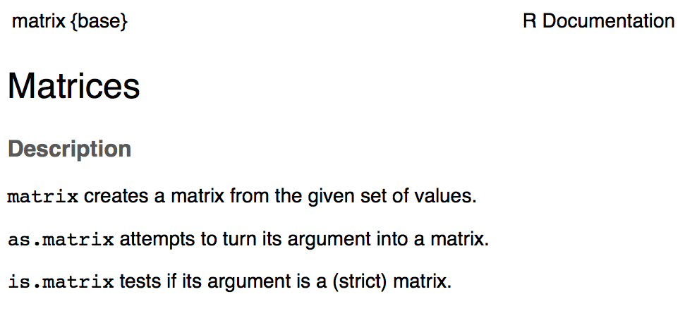